# 4PL curve fitting

2022-12-09

# 1 Initialization

```
##
## 'nlstools' has been loaded.
```

```
## IMPORTANT NOTICE: Most nonlinear regression models and data set examples
```

```
## related to predictive microbiolgy have been moved to the package 'nlsMicrobio'
```

# 2 Data loading and processing

```
## Loading dataset...
```

```
##    conc       X1       X2       X3       X4       X5       X6
## 1    -6 1.010479 1.077564 1.106223 0.987762 0.986955 0.944235
## 2    -5 1.010479 1.077564 1.106223 0.987762 0.986955 0.944235
## 3    -4 1.010479 1.077564 1.106223 0.987762 0.986955 0.944235
## 4    -3 1.010479 1.077564 1.106223 0.987762 0.986955 0.944235
## 5    -2 1.010479 1.077564 1.106223 0.987762 0.986955 0.944235
## 6    -1 0.864400 0.849164 0.906683 0.869614 0.820936 0.775740
## 7     0 0.464446 0.529206 0.492726 0.511687 0.548372 0.491318
## 8     1 0.274938 0.283498 0.296118 0.276790 0.291130 0.298531
## 9     2 0.070258 0.075610 0.078598 0.077952 0.073403 0.064114
## 10    3 0.070258 0.075610 0.078598 0.077952 0.073403 0.064114
```

```
## 'data.frame':    60 obs. of  3 variables:
##  $ conc    : num  1e-06 1e-06 1e-06 1e-06 1e-06 1e-06 1e-05 1e-05 1e-05 1e-05 ...
##  $ variable: Factor w/ 6 levels "X1","X2","X3",..: 1 2 3 4 5 6 1 2 3 4 ...
##  $ od      : num  1.01 1.078 1.106 0.988 0.987 ...
```

```
## Descriptive statistics.
```

```
##     conc n   mean.od       var.od
## 1  1e-06 6 1.0188697 3.740520e-03
## 2  1e-05 6 1.0188697 3.740520e-03
## 3  1e-04 6 1.0188697 3.740520e-03
## 4  1e-03 6 1.0188697 3.740520e-03
## 5  1e-02 6 1.0188697 3.740520e-03
## 6  1e-01 6 0.8477562 2.026957e-03
## 7  1e+00 6 0.5062925 8.968457e-04
## 8  1e+01 6 0.2868342 9.899875e-05
## 9  1e+02 6 0.0733225 2.973799e-05
## 10 1e+03 6 0.0733225 2.973799e-05
```

```
## Min and max values.
```

```
##     conc n      Min      Max
## 1  1e-06 6 0.944235 1.106223
## 2  1e-05 6 0.944235 1.106223
## 3  1e-04 6 0.944235 1.106223
## 4  1e-03 6 0.944235 1.106223
## 5  1e-02 6 0.944235 1.106223
## 6  1e-01 6 0.775740 0.906683
## 7  1e+00 6 0.464446 0.548372
## 8  1e+01 6 0.274938 0.298531
## 9  1e+02 6 0.064114 0.078598
## 10 1e+03 6 0.064114 0.078598
```

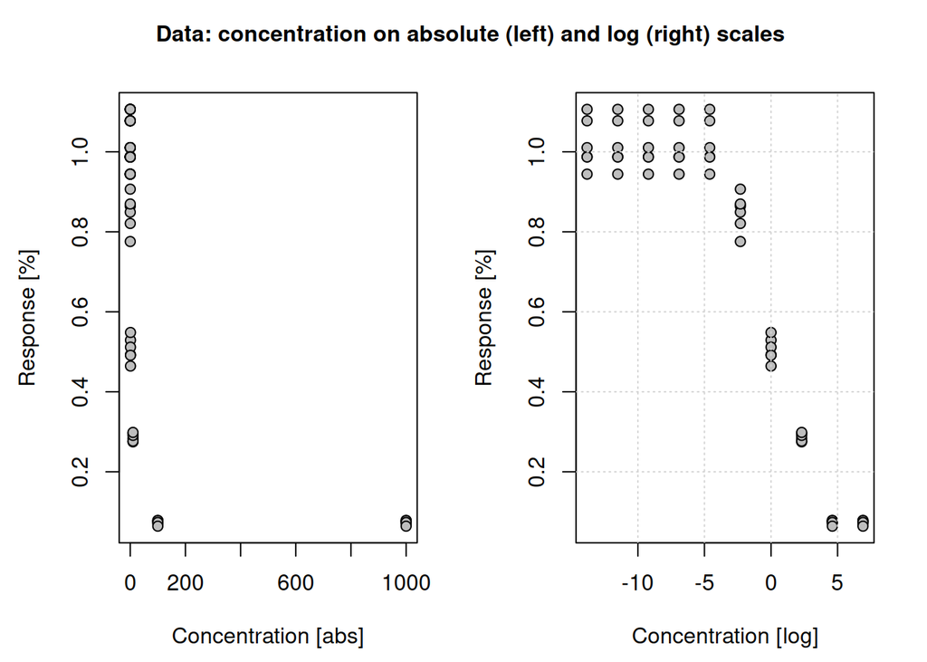

# 3 Modeling the variability with variance regression

Checking mean response and variance of the response with power function (Dunn and Wild 2013): `Var(y)=intercept∗Mean(y)^theta`

Linearised function: `log(Var(y))=log(intercept)+theta∗log(Mean(y))`

```
##
## Call:
## lm(formula = log.var.od ~ log.mean.od, data = DF.sum)
##
## Residuals:
##      Min       1Q   Median       3Q      Max
## -1.10466  0.05376  0.13492  0.13492  0.26706
##
## Coefficients:
##             Estimate Std. Error t value Pr(>|t|)
## (Intercept)  -5.7587     0.1660  -34.69 5.22e-10 ***
## log.mean.od   1.8873     0.1325   14.25 5.74e-07 ***
## ---
## Signif. codes:  0 '***' 0.001 '**' 0.01 '*' 0.05 '.' 0.1 ' ' 1
##
## Residual standard error: 0.4289 on 8 degrees of freedom
## Multiple R-squared:  0.9621, Adjusted R-squared:  0.9573
## F-statistic:   203 on 1 and 8 DF,  p-value: 5.74e-07
```

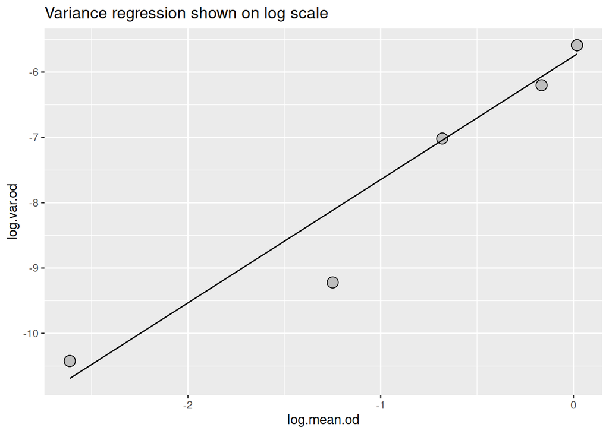

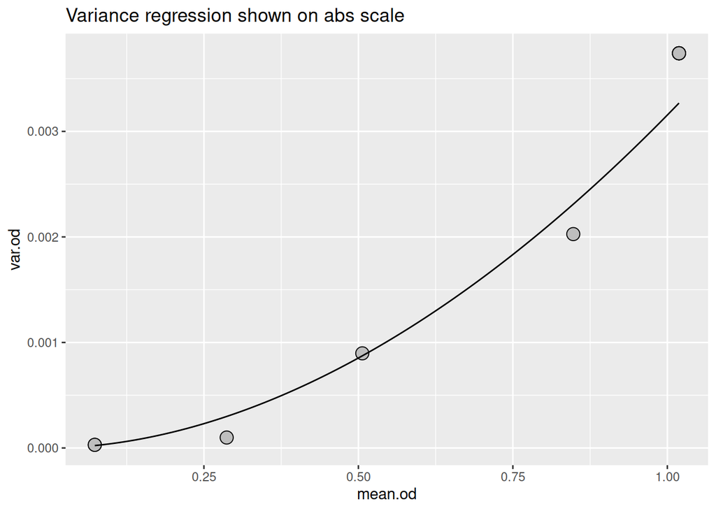

```
##                 2.5 %    97.5 %
## (Intercept) -6.141574 -5.375893
## log.mean.od  1.581862  2.192820
```

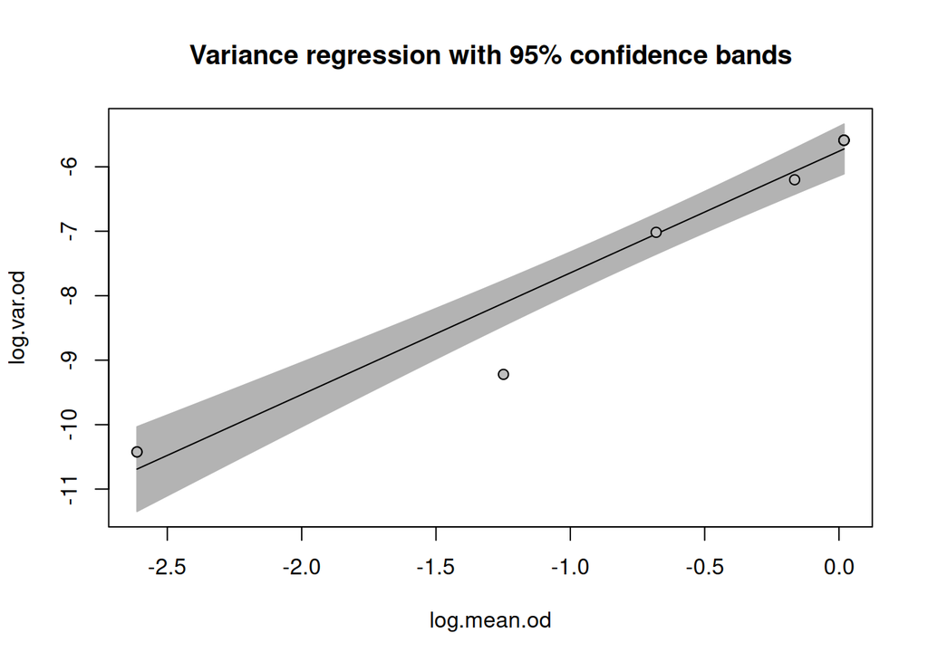

# 4 Curve fitting

## 4.1 Unweighted nonlinear regression

```
##
## Formula: od ~ M.4pl(conc, Top, Bottom, IC50, slope)
##
## Parameters:
##        Estimate Std. Error t value Pr(>|t|)
## Top     1.03081    0.01073  96.044  < 2e-16 ***
## Bottom  0.05548    0.02019   2.748  0.00806 **
## IC50    0.97938    0.13961   7.015 3.27e-09 ***
## slope  -0.63036    0.05003 -12.599  < 2e-16 ***
## ---
## Signif. codes:  0 '***' 0.001 '**' 0.01 '*' 0.05 '.' 0.1 ' ' 1
##
## Residual standard error: 0.05134 on 56 degrees of freedom
##
## Number of iterations to convergence: 8
## Achieved convergence tolerance: 1.49e-08
```

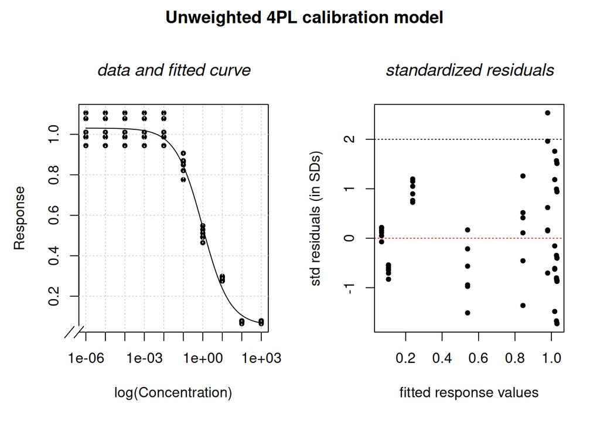

## 4.2 Weighted nonlinear regression

```
##
## Formula: od ~ M.4pl(conc, Top, Bottom, IC50, slope)
##
## Parameters:
##         Estimate Std. Error t value Pr(>|t|)
## Top     1.015162   0.023105  43.937  < 2e-16 ***
## Bottom  0.057188   0.005278  10.836 2.30e-15 ***
## IC50    1.208851   0.184614   6.548 1.93e-08 ***
## slope  -0.698510   0.049175 -14.205  < 2e-16 ***
## ---
## Signif. codes:  0 '***' 0.001 '**' 0.01 '*' 0.05 '.' 0.1 ' ' 1
##
## Residual standard error: 0.1207 on 56 degrees of freedom
##
## Number of iterations to convergence: 11
## Achieved convergence tolerance: 1.49e-08
```

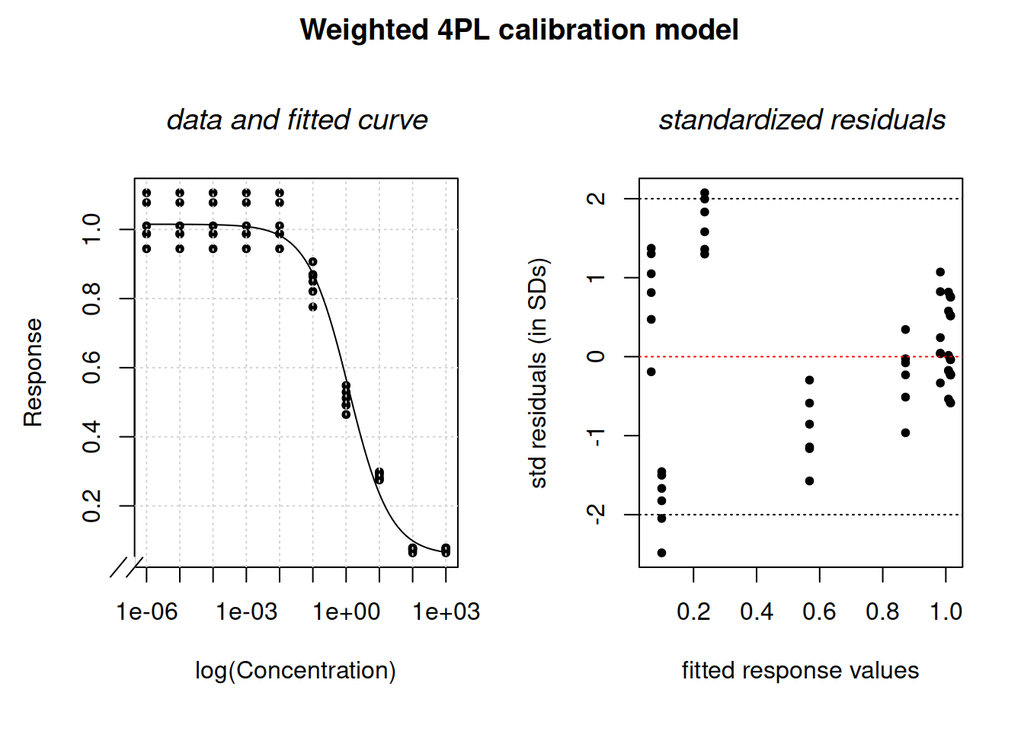

```
## What are the parts of the model object and summary object
```

```
## Weights
```

```
##  [1]   0.9446284   0.9446284   0.9446284   0.9446284   0.9446284   0.9446284
##  [7]   0.9455511   0.9455511   0.9455511   0.9455511   0.9455511   0.9455511
## [13]   0.9494948   0.9494948   0.9494948   0.9494948   0.9494948   0.9494948
## [19]   0.9664073   0.9664073   0.9664073   0.9664073   0.9664073   0.9664073
## [25]   1.0399778   1.0399778   1.0399778   1.0399778   1.0399778   1.0399778
## [31]   1.3780806   1.3780806   1.3780806   1.3780806   1.3780806   1.3780806
## [37]   3.2000212   3.2000212   3.2000212   3.2000212   3.2000212   3.2000212
## [43]  14.9450757  14.9450757  14.9450757  14.9450757  14.9450757  14.9450757
## [49]  69.6344128  69.6344128  69.6344128  69.6344128  69.6344128  69.6344128
## [55] 161.0994115 161.0994115 161.0994115 161.0994115 161.0994115 161.0994115
```

```
## Weights mean
```

```
## [1] 25.51031
```

```
## Weights sum
```

```
## [1] 1530.618
```

```
## Unweighted residuals
```

```
##  [1] -0.004629219  0.062455781  0.091114781 -0.027346219 -0.028153219
##  [6] -0.070873219 -0.004413398  0.062671602  0.091330602 -0.027130398
## [11] -0.027937398 -0.070657398 -0.003336889  0.063748111  0.092407111
## [16] -0.026053889 -0.026860889 -0.069580889  0.002003927  0.069088927
## [21]  0.097747927 -0.020713073 -0.021520073 -0.064240073  0.027811166
## [26]  0.094896166  0.123555166  0.005094166  0.004287166 -0.038432834
## [31] -0.007829522 -0.023065522  0.034453478 -0.002615522 -0.051293522
## [36] -0.096489522 -0.103412289 -0.038652289 -0.075132289 -0.056171289
## [41] -0.019486289 -0.076540289  0.039520517  0.048080517  0.060700517
## [46]  0.041372517  0.055712517  0.063113517 -0.028851230 -0.023499230
## [51] -0.020511230 -0.021157230 -0.025706230 -0.034995230  0.004372825
## [56]  0.009724825  0.012712825  0.012066825  0.007517825 -0.001771175
## attr(,"label")
## [1] "Residuals"
```

```
## Unweighted sum of squares - use to compare models
```

```
## [1] 0.1642886
```

```
## Unweighted MSE
```

```
## [1] 0.002933724
```

```
## Unweighted RSE
```

```
## [1] 0.05416387
```

```
## Weighted residuals - use this for plotting
```

```
##  [1] -0.004499230  0.060702020  0.088556274 -0.026578336 -0.027362675
##  [6] -0.068883096 -0.004291564  0.060941524  0.088809379 -0.026381450
## [11] -0.027166173 -0.068706868 -0.003251532  0.062117449  0.090043359
## [16] -0.025387437 -0.026173794 -0.067801026  0.001969980  0.067918571
## [21]  0.096092092 -0.020362197 -0.021155527 -0.063151857  0.028361633
## [26]  0.096774448  0.126000696  0.005194995  0.004372022 -0.039193536
## [31] -0.009191207 -0.027077003  0.040445517 -0.003070405 -0.060214326
## [36] -0.113270669 -0.184990140 -0.069143546 -0.134401170 -0.100482590
## [41] -0.034858249 -0.136919885  0.152781818  0.185873804  0.234661287
## [46]  0.159941440  0.215378247  0.243989670 -0.240755541 -0.196094580
## [51] -0.171160546 -0.176551237 -0.214511385 -0.292025523  0.055502059
## [56]  0.123432289  0.161357462  0.153158111  0.095419954 -0.022480625
```

```
## Weighted sum of squares
```

```
## [1] 0.8158512
```

```
## RSE (sigma) - weighted
```

```
## [1] 0.1207012
```

## 4.3 Iteratively reweighted least squares algorithm

### 4.3.1 Curve fitting

We need to estimate both the parameters of the 4PL function as well as the weight function. This can be done by iteratively applying the nlsLM function described above till the residual sum of squares does not reduce significantly. Below is a function that implements this iterative model fitting process. This is the same approach used in the GraphPad software program.

```
##
## The unweighted model:
##
## Formula: od ~ M.4pl(conc, Top, Bottom, IC50, slope)
##
## Parameters:
##        Estimate Std. Error t value Pr(>|t|)
## Top     1.03081    0.01073  96.044  < 2e-16 ***
## Bottom  0.05548    0.02019   2.748  0.00806 **
## IC50    0.97938    0.13961   7.015 3.27e-09 ***
## slope  -0.63036    0.05003 -12.599  < 2e-16 ***
## ---
## Signif. codes:  0 '***' 0.001 '**' 0.01 '*' 0.05 '.' 0.1 ' ' 1
##
## Residual standard error: 0.05134 on 56 degrees of freedom
##
## Number of iterations to convergence: 8
## Achieved convergence tolerance: 1.49e-08
##
## ---------------------------------------------------
## The weighted sum of squares was stable after 8 cycles
##
## ---------------------------------------------------
## The final model:
##
## Formula: od ~ M.4pl(conc, Top, Bottom, IC50, slope)
##
## Parameters:
##         Estimate Std. Error t value Pr(>|t|)
## Top     1.012174   0.023245   43.54  < 2e-16 ***
## Bottom  0.057714   0.005153   11.20 6.42e-16 ***
## IC50    1.282016   0.200953    6.38 3.64e-08 ***
## slope  -0.719810   0.052072  -13.82  < 2e-16 ***
## ---
## Signif. codes:  0 '***' 0.001 '**' 0.01 '*' 0.05 '.' 0.1 ' ' 1
##
## Residual standard error: 0.124 on 56 degrees of freedom
##
## Number of iterations to convergence: 12
## Achieved convergence tolerance: 1.49e-08
```

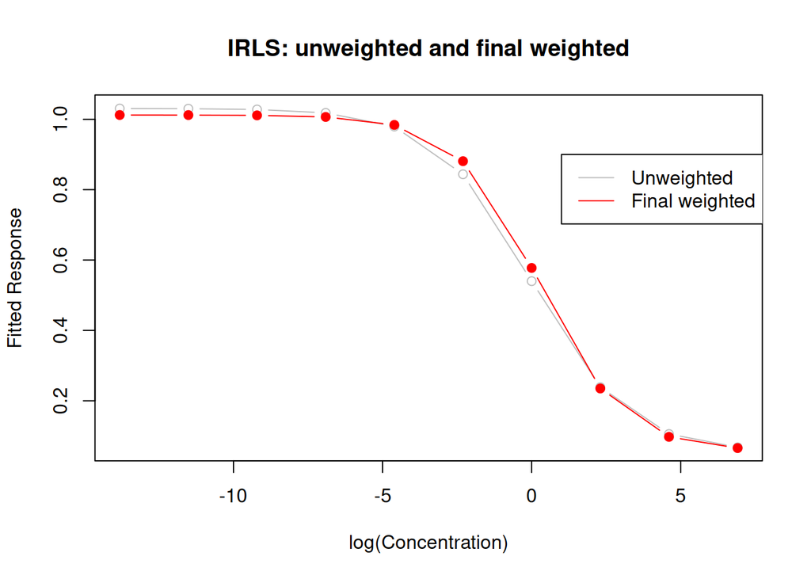

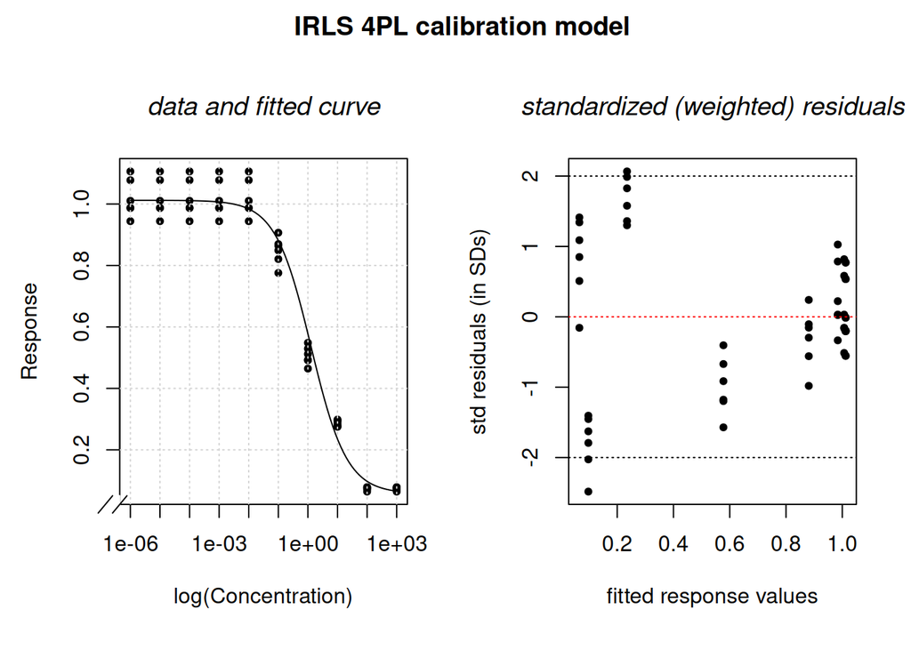

```
## CI95%
```

```
##           2.5 %   97.5 %
## Top     0.96561  1.05874
## Bottom  0.04739  0.06804
## IC50    0.87946  1.68457
## slope  -0.82412 -0.61550
```

```
## Weighted sum of squares
```

```
## [1] 0.861
```

```
## Sigma (RSE). Residual Standard Error (R'’'s sigma and GraphPad'’'s Sy.x) are virtually the same.
```

```
## [1] 0.124
```

### 4.3.2 Error model

The following function returns a data frame of triplets: a range of response values (`yp`), corresponding predicted concentration (`xp`) and the standard deviation of the predicted concentration (`sd.xp`). Derive var(x) from calibration curve model. Adapted from S-PLUS code at http://lib.stat.cmu.edu/S/calibration. Values from vcov(model) = unscaled * sigma^2 but sumary(model)$cov.unscaled is what we need. O’Connell p.103 (left column, about 1/2 page): “denotes the estimated covariance matrix for [beta-hat], unscaled by [sigma-hat]…” conf is confidence level for prediction interval

```
##           yp          xp       sd.xp
## 1  1.0121357 0.000001000 0.002758271
## 2  0.9982706 0.003674396 0.027760621
## 3  0.9894916 0.007347792 0.033994340
## 4  0.9820479 0.011021189 0.038393751
## 5  0.9753843 0.014694585 0.041945314
## 6  0.9692627 0.018367981 0.044995236
## 7  0.9635518 0.022041377 0.047709418
## 8  0.9581691 0.025714773 0.050181308
## 9  0.9530583 0.029388170 0.052469150
## 10 0.9481786 0.033061566 0.054611882
## 11 0.9434994 0.036734962 0.056636911
## 12 0.9389966 0.040408358 0.058564311
## 13 0.9346511 0.044081755 0.060409251
## 14 0.9304472 0.047755151 0.062183490
## 15 0.9263718 0.051428547 0.063896344
```